# The Obesity and Fast Food Project - novel use of the pair correlation function

Nightingale et al

2026-06-21

# Metric for measuring foodscapes - Scottish LAs

In this journal we present a novel approach to describing foodscapes; the use of the pair correlation function. The pair correlation function (@Diggle 1983; @Baddeley et al. 2007; @Stoyan and Penttinen 2000; @Illian et al. 2008; @Law et al. 2009, @Nightingale et.al,2015a, @Nightingale et.al, 2015b) is a tool commonly used to describe secondary order summary statistics for point patterns. Before describing our use of the pair correlation in the context of foodscapes we present a brief summary of point patterns, and point pattern statistics because, essentially the dataset under consideration is a marked point pattern.

## Point pattern statistics

### What’s the **pOint** in point pattern statistics?

Point patterns represent the xy location of objects or event occurrences in the space. Typically point patterns are classed in either of three groupings; clustered, regular and random (@Nightingale , 2020a, @Nightingale 2020b).

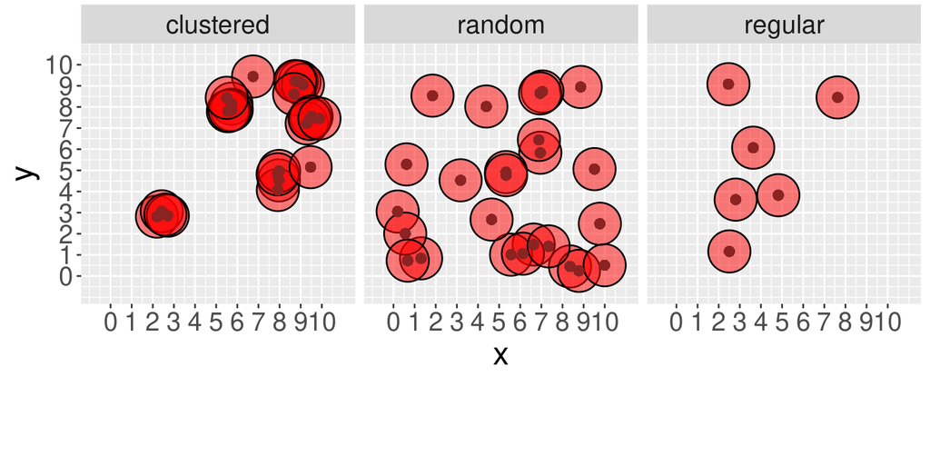

#### Clustered point patterns

The clustered point pattern would consist of clusters of points with gaps in between. Additionally, a clustered point pattern can be considered to contain points which are situated closer to each other than would be expected for points which are situated/located completely at random.In fact, a point pattern with points that are situated completely at random are formally described as exhibiting “Complete Spatial Randomness” (CSR). Importantly, the “reference” point pattern which exhbits CSR and to which other point patterns can be compared to is the **homogeneous Poisson point process**. In terms of usage and interpretability, a clustered point pattern is thought to represent objects or events which tend to associate together. In particular some authors suggest that the points in such point patterns are representative of some degree of underlying “attraction” between the objects/events which they denote.

#### Regular point patterns

A regular point pattern, unlike the clustered, and random point patterns contains points which are distributed/situated in an ordered fashion. This distribution is more ordered than would be expected for points in a point pattern which exhibits CSR. The underlying interaction between objects/events denoted by the points in a regular point pattern is that of inhibition and described as a “negative” interaction.

#### Random point patterns

As described earlier, the point pattern which consists of a random distribution of points exhibits CSR and the **homogeneous Poisson point process** is an exemplar. The points in random point patterns are not dependent on each other, not ordered systemmatically, and there is no underlying interaction associated with their distribution.

#### Marked point patterns

For a given point pattern, each point represents one object/event. Additional information on each object (apart from its spatial location) may also be available. This additional information or ‘mark’(@Nightingale et al, 2019; @Baddeley et al, 2000), associated with each point is considered to be an ‘attribute’ of that point. @Baddeley et al (2000) note that a mark can be thought of as an additional coordinate for each point in the spatial pattern. A point pattern representing points which possess such additional information is classified as a marked point pattern. Examples of such point attributes are: tree diameter breast height, number of eggs in nest, weight of eggs, animal/plant species and COVID-19 positivity.

Note that marks can be qualitative/categorical such as species or quantitative/continuous such as average COVID-19 positivity. If the marks are qualitative, the marked point pattern is a multitype point pattern. This point pattern would be associated with different subpatterns, each representing one particular mark of the mark type. An example of this is a point pattern representing different plant species such that the mark is a quantitative discrete mark corresponding to the species of the plant.

Mathematically, for a given marked multitype point pattern $\mathbf{x}$ in a bounded region in space $W$, with $n$ individual marks, there exists $n$ subpatterns, $x_{1:n}$ such that $\mathbf{x} = {x_{1}, ...x_{n}}$. Finally, a mark can be multivariate in nature, such that each mark represents a list of attributes/variables relating to every point represented in the pattern.

# The pair correlation function as a diagnostic tool

The pair correlation function (g(r)) allows us to view the spatial distribution of the points denoting the fast food outlets over different spatial scales (@Nightingale et.al, 2019). In particular, we can see whether the points are clustered, regular, or randomly distributed and over which spatial scales.

For a given fast food outlet, A, the pair correlation function, or g(r), estimates how likely one would find another fast food outlet a distance r from A relative to what would be obtained in a point pattern which exhitis complete spatial randomness (CSR). If g(r) is =1,greater than 1 or less than 1, we would conclude that the fast food outlets are distributed randomly at distance r, clustered at distance r and regular (displaying inhibition) at distance r, respectively.

In @Nightingale et.al (2015) we note that g(r) can be described mathematically as:
$$g(r) = K'(r)/2\pi r$$
where $K(r)$ is Ripley’s K function. The authors also provide visualization of the output of the pair correlation for two contrasting point patterns (as seen below). One pattern is a clustered pattern, and the other is one displaying CSR.

The corresponding pair correlation functions depict these accordingly. The solid black line denotes g(r) for the observed data, the dotted red line for a reference pattern (homogenous Poisson) exibiting CSR, and the simulation envelopes (1000 in total) are separate instances of g(r) for a point pattern with CSR.

For each point pattern case a simulation envelope is included in the plot of the pair correlation function. The simulation envelope contains instances of the pair correlation function for a reference pattern with CSR.

For the clustered pattern, the pair correlation function can be seen above the simulation envelope at a narrow spatial range. For the random pattern, the pair correlation function is seen to be predominantly within the simulation envelope.

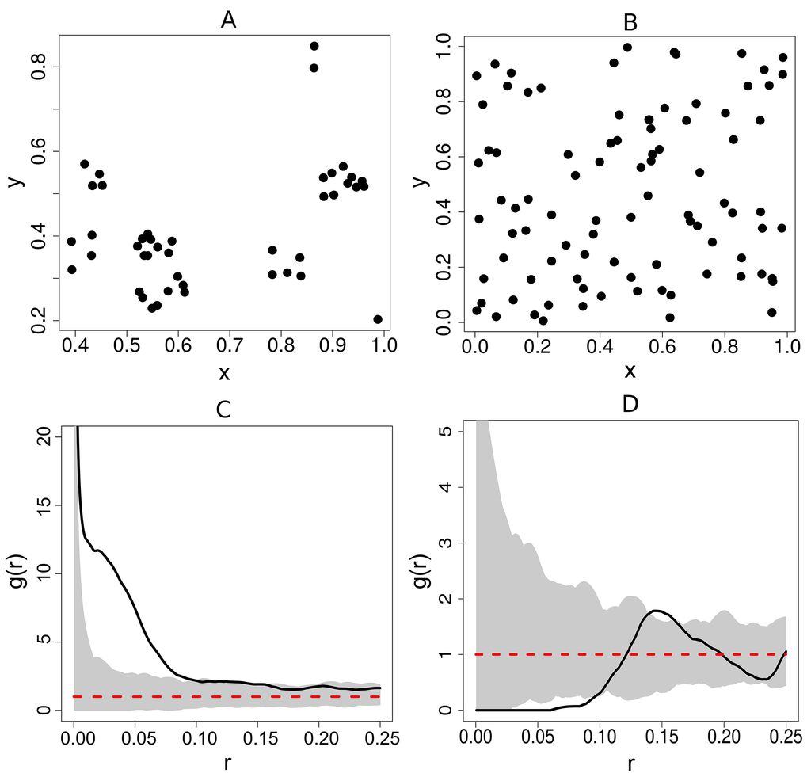

The use of the pair correlation function to characterise the foodscapes regarding fast food outlets in Scotland is novel and we will illustrate its use with examples below.

Below it is clear that for SIMD Decile 1, there is spatial clustering of fast food outlets over a wide spatial range (multiple spatial scales) and in SIMD Decile 10, there is clustering at isolated and narrow spatial scales. This suggests an inequality in the food environment in these contrasting SIMD Deciles.

### The pair correlation function for two contrasting SIMD Deciles

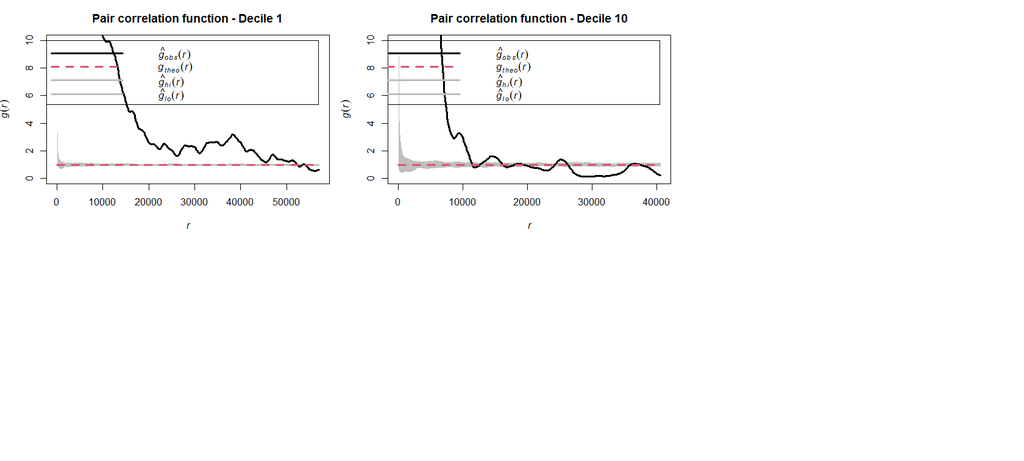

### The pair correlation function for selected Scottish Local Authorities

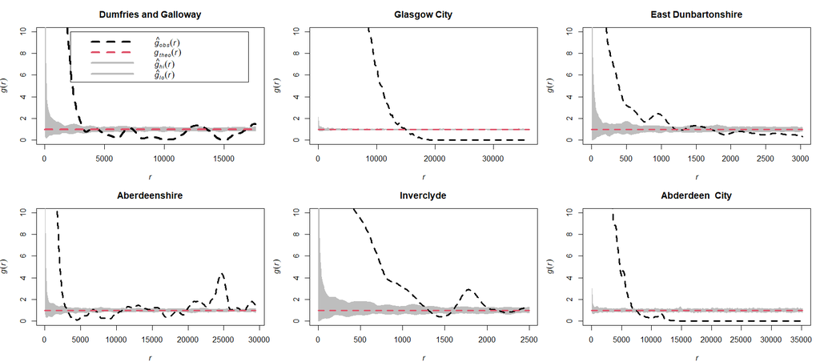

A further six Local Authorities are shown below.

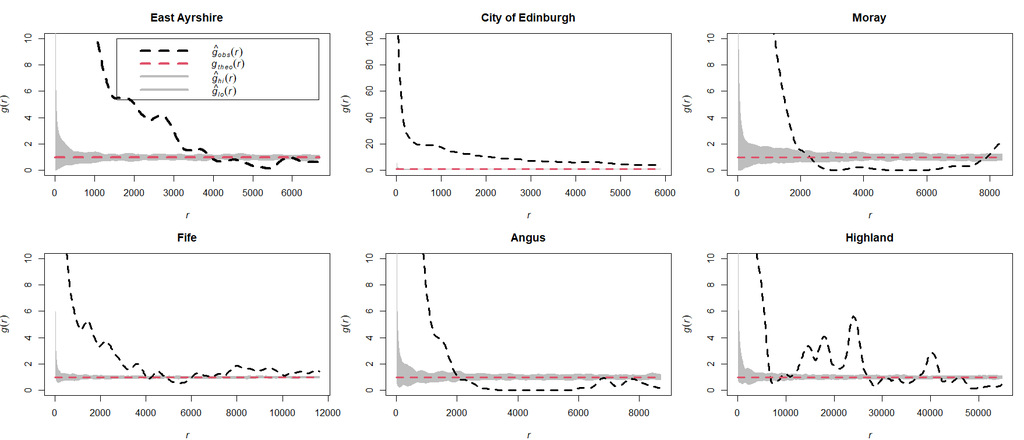

# References

1. Nightingale, G.F., Illian, J.B., King, R. and Nightingale, P., 2019. Area interaction point processes for bivariate point patterns in a Bayesian context. Journal of Environmental Statistics, 9(2).
2. Nightingale, G.F., Laland, K.N., Hoppitt, W. and Nightingale, P., 2015. Bayesian spatial NBDA for diffusion data with home-base coordinates. PLoS One, 10(7), p.e0130326.
3. Nightingale, 2020: Point Patterns: https://thestatsclinic.shinyapps.io/point-pattern-analyses-an-introduction/#section-point-pattern-characteristics
4. Nightingale, 2020 Area Interactions: https://rpubs.com/loggaussian/areainteraction
5. Nightingale, G.F., Illian, J.B. and King, R., 2015. Pairwise interaction point processes for modelling bivariate spatial point patterns in the presence of interaction uncertainty. Journal of Environmental Statistics, 7(3).
6. Law R, Illian J, Burslem DFRP, Gratzer G, Gunatilleke CVS, Gunatilleke IAUN (2009). “Ecological information from spatial patterns of plants insights from point process theory.” Journal of Ecology, 97, 616–628.
7. Illian J, Penttinen A, Stoyan H, Stoyan D (2008). Statistical Analysis and Modelling of Spatial Point Patterns. John Wiley and Sons, Chichester.
8. Baddeley A, B´ar´any I, Schneider R (2007). “Spatial Point Processes and their Applications.” In Stochastic Geometry, volume 1892 of Lecture Notes in Mathematics, pp. 1–75. Springer Berlin / Heidelberg.
9. Baddeley, A. and Turner, R., 2000. Practical Maximum Pseudolikelihood for Spatial Point Patterns: (with Discussion). Australian & New Zealand Journal of Statistics, 42(3), pp.283-322.
10. Stoyan D, Penttinen A (2000). “Recent applications of point process methods in forestry statistics.” Statistical Science, 15, 61–78.
11. Diggle PJ (1983). Statistical analysis of spatial point patterns. Academic Press Inc.